# CNARA tutorial

This is a tutorial demonstrating the basic usage of the CNARA R software. Before we start please download the software repository from https://github.com/baudisgroup/CNARA and set the working directory to the downloaded repository.

*CNARA.R* is the source code.  
*code_tuto.R* is the sample code for the full usage of the CNARA software.  
*trainingSet.txt* contains the 1522 training samples as used in the CNARA paper https://bmcgenomics.biomedcentral.com/articles/10.1186/s12864-016-3074-7.

The dataset we are going to use in this tutorial can be found in the *sample* folder. The sample contains 1 series named *sample_series*, in which 5 samples are included. For each sample, there are 2 tab-delimited files, i.e. probe file *CNprobes.tab* and segmentation file *segments.tab* (segmentation file can be omitted). *CNprobes.tab* contains 4 columns, which are ID, chromosome, genomic position and the corresponding log2 copy number value. *segments.tab* contains 6 columns, which are sample id, chromosome, segment start-position, segment stop-position, the mean value for the segment and the number of probes contained in the segment.

1. To begin with, install dependency packages *robfilter*, *DNAcopy*, *kernlab* and *e1071* if you don’t have them. Load the CNARA source file.

```r
#install.packages(c("robfilter", "DNAcopy", "kernlab", "e1071"))
source("CNARA.R")
```

2. Specify the corresponding directories and files

```r
workPath <- getwd()
samplePath <- file.path(workPath, "sample")
series <- "sample_series"
probeFileName <- "CNprobes.tab"
segFileName <- "segments.tab"

trainingFile <- file.path(workPath, "trainingSet.txt")
outputFile <- file.path(workPath, "out.txt")

arrayDir <- file.path(samplePath, series)
arrayList <- list.files(arrayDir)
noArray <- length(arrayList)
```

3. Pick a random array in the series as an example.

```r
arr <- 5
probeFile <- file.path(arrayDir, arrayList[arr], probeFileName)
segFile <- file.path(arrayDir, arrayList[arr], segFileName)
```

4. Read in the probe file and create a CNProbe object.

```r
newCNProbe <- readProbe(probeFile=probeFile, sampleID=arrayList[arr])
```

5. Call the method calSpeakCNAno() which performs the step-fitting algorithm estimating the number of steps and the peak value of S.

```r
newSpeakCNAno <- calSpeakCNAno(newCNProbe)
```

6. The number of segments detected by CBS for the normalised copy number profile

```r
segNumberCBS <- calCBSBreakpoints(newCNProbe)
```

```
## Analyzing: GSM491138
```

```r
segNumberCBS
```

```
## [1] 32
```

7. The derivative log ratio spread (DLRS) of the probes

```r
segSpread <- calSpread(newCNProbe, segFile=segFile)
#segSpread <- calSpread(newCNProbe) # if you don't have segmentation file
segSpread
```

```
## [1] 0.254741
```

8. Plot the S graph

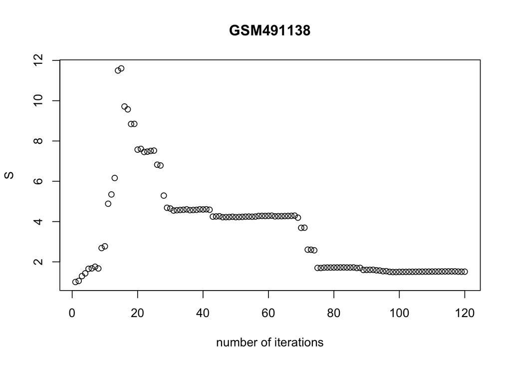

```r
plot(quality(newSpeakCNAno), xlab = "number of iterations", ylab = "S", main=arrayList[arr])
```

9. The number of segments detected by step-fitting and the peak value of *S* as defined in the paper

```r
CNAno <- numberOfCNA(newSpeakCNAno)
Speak <- speak(newSpeakCNAno)

CNAno
```

```
## [1] 15
```

```r
Speak
```

```
## [1] 11.60217
```

10. Create a new object “Metrics” for the copy number profile for quality assessment

```r
CNProfileMetrics <- createMetrics(sampleID=arrayList[arr], speak=Speak, numberOfCNA=CNAno, cbsBreakpoints=segNumberCBS, spread=segSpread)
```

11. Train a SVM classifier on the training set. The parameters are chosen as explained in the paper.

```r
classifier <- trainSVM(trainingFile)
```

12. Quality assessment for the copy number profile

```r
assessment <- assessQuality(CNProfileMetrics, svmClassifier=classifier)
assessment
```

```
##   label decision.values flag
## 1     1        1.735905 good
##                                           caseDiag
## 1 2: good quality, discernible CNAs with few waves
```

13. Plot a best fit and counter-fit for a copy number profile.

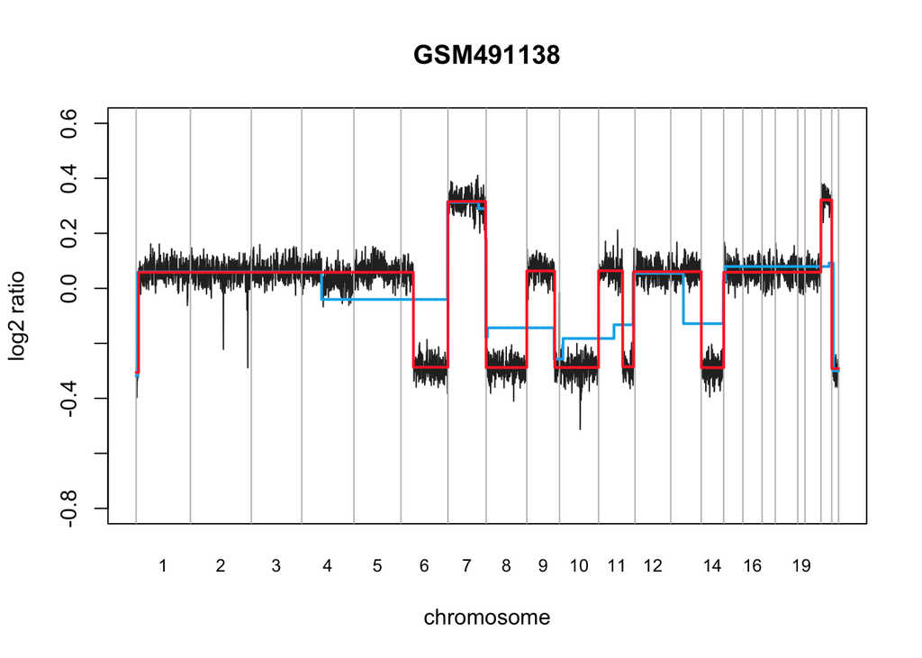

```r
plotFCF(calSpeakCNAno(newCNProbe, iterations=CNAno))
```

Please also refer to *code_tuto.R* for executable code.